# Machine Learning Algorithm Tuning with mlr3

# Intro

In this case we will continue working with the **German Credit Dataset**. Yesterday we peeked into the data set by using and comparing some learners with ther default parameters. We will now see how to:

- Tune hyperparameters for a given problem
- Perform nested resampling
- Adjust decision thresholds

# Prerequisites

We expect you have installed all packages from day 1. If not, load the day 1 script and run the **Prerequisites** install chunk.

Load the packages we are going to use:

```r
library("data.table")
library("mlr3")
library("mlr3learners")
library("ggplot2")
theme_set(theme_light())
```

We use the same data as yesterday.

```r
credit = readRDS("credit.rds")
task = TaskClassif$new("GermanCredit", credit, "class")
```

Also, because tuning often takes a long time, we want to make more efficient use of our multicore CPUs. Don’t do this on rstudio cloud, however.

```r
# future::plan("multiprocess")
```

## Evaluation

We evaluate all algorithms using 10-fold cross-validation. We use a *fixed* train-test split, i.e. the same splits for each evaluation. Otherwise, some evaluation could get unusually “hard” splits, which would make comparisons unfair.

```r
set.seed(8008135)
cv10_instance = rsmp("cv", folds = 10)
# fix the train-test splits using the $instantiate() method
cv10_instance$instantiate(task)
# have a look at the test set instances per fold
cv10_instance$instance
```

```
#>       row_id fold
#>    1:      5    1
#>    2:     20    1
#>    3:     28    1
#>    4:     35    1
#>    5:     37    1
#>   ---
#>  996:    936   10
#>  997:    950   10
#>  998:    963   10
#>  999:    985   10
#> 1000:    994   10
```

# Simple Parameter Tuning

- Use the `paradox` package for search space definition of the hyperparameters
- Use the `mlr3tuning` package for tuning the hyperparameters

```r
library("mlr3tuning")
library("paradox")
```

## Search Space and Problem Definition

- First need to decide what `Learner` to optimize. We will use `"classif.kknn"`, the “kernelized” k-nearest neighbor classifier.
- We will use `kknn` as a normal kNN without weighting first (i.e., use the `rectangular` kernel):

```r
knn = lrn("classif.kknn", predict_type = "prob")
# use rectangular kernel for normal kNN
knn$param_set$values$kernel = "rectangular"
```

- Then we decide what parameters we optimize over. What are our options?

```r
knn$param_set
```

```
#> ParamSet:
#>          id    class lower upper                                                         levels default
#> 1:        k ParamInt     1   Inf                                                                      7
#> 2: distance ParamDbl     0   Inf                                                                      2
#> 3:   kernel ParamFct    NA    NA rectangular,triangular,epanechnikov,biweight,triweight,cos,... optimal
#> 4:    scale ParamLgl    NA    NA                                                     TRUE,FALSE    TRUE
#>          value
#> 1:
#> 2:
#> 3: rectangular
#> 4:
```

- We first tune the `k` parameter from 3 to 20 and the `distance` function (either L1 or L2). To do so, we use the `paradox` package to define a search space (see Appendix for a short list of possible parameter types).

```r
searchspace = ParamSet$new(list(
  ParamInt$new("k", lower = 3, upper = 20),
  ParamInt$new("distance", lower = 1, upper = 2)
))
```

- We define a “tuning instance” that represents the problem we are trying to optimize.
  - What is the task we are optimizing for?
  - What learner are we using?
  - How do we do resampling?
  - What is the performance measure?
  - What is the search space (“parameter set”)?
  - When are we done searching? (Disregard this for now).

```r
instance_grid = TuningInstance$new(
  task = task,
  learner = knn,
  resampling = cv10_instance,
  measures = msr("classif.ce"),
  param_set = searchspace,
  terminator = term("none")
)
```

## Grid Search

- A simple tuning method is to try all possible combinations of parameters: **Grid Search**
  - Pro: Very intuitive and simple
  - Con: Inefficient if the search space is large
- We get the `"grid_search"` tuner for this

```r
set.seed(1)
tuner_grid = tnr("grid_search", resolution = 18, batch_size = 36)
```

- Tuning works by calling `$tune()`. Note that it *modifies* our “tuning instance”–the result can be found in the `instance` object.

```r
# empty instance object:
instance_grid$result
```

```
#> $tune_x
#> NULL
#>
#> $params
#> $params$kernel
#> [1] "rectangular"
#>
#>
#> $perf
#> NULL
```

```r
# now run tuning:
tuner_grid$tune(instance_grid)
```

- The result can be found in the `$result` slot. We can also plot the performance.

```r
instance_grid$result
```

```
#> $tune_x
#> $tune_x$k
#> [1] 13
#>
#> $tune_x$distance
#> [1] 2
#>
#>
#> $params
#> $params$kernel
#> [1] "rectangular"
#>
#> $params$k
#> [1] 13
#>
#> $params$distance
#> [1] 2
#>
#>
#> $perf
#> classif.ce
#>      0.253
```

- We can look at the “archive” of evaluated configurations
- We expand the “params” (the parameters that the `Learner` actually saw)

```r
perfdata = instance_grid$archive("params")
perfdata[, c("nr", "k", "distance", "classif.ce")]
```

```
#>     nr  k distance classif.ce
#>  1:  1  3        1      0.274
#>  2:  2  3        2      0.284
#>  3:  3  4        1      0.274
#>  4:  4  4        2      0.284
#>  5:  5  5        1      0.295
#>  6:  6  5        2      0.258
#>  7:  7  6        1      0.295
#>  8:  8  6        2      0.258
#>  9:  9  7        1      0.267
#> 10: 10  7        2      0.256
#> 11: 11  8        1      0.267
#> 12: 12  8        2      0.256
#> 13: 13  9        1      0.262
#> 14: 14  9        2      0.255
```

[output cut: 23 more lines]

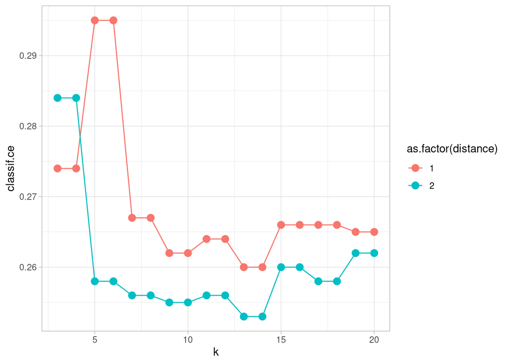

```r
ggplot(perfdata, aes(x = k, y = classif.ce, color = as.factor(distance))) +
  geom_line() + geom_point(size = 3)
```

- Euclidean distance (`distance` = 2) seems to work better, but there is much randomness introduced by the resampling instance, so you may see a different result!
- `k` between 10 and 15 perform well

## Random Search and Transformation

- Let’s look at a larger search space. In fact, how about we tune *all* available parameters and limit `k` to large values (50).
- **Problem 1**: The difference in performance between `k` = 3 and `k` = 4 is probably larger than the difference between `k` = 49 and `k` = 50.
  - We will use a **transformation function** for `k` and sample values on the log-space.
  - To do so, we define the range for `k` from `log(3)` to `log(50)` and exponentiate in the transformation.
  - For `k`, we must use `ParamDbl` instead of `ParamInt` now!

```r
large_searchspace = ParamSet$new(list(
  ParamDbl$new("k", lower = log(3), upper = log(50)),
  ParamDbl$new("distance", lower = 1, upper = 3),
  ParamFct$new("kernel", c("rectangular", "gaussian", "rank", "optimal")),
  ParamLgl$new("scale")
))

large_searchspace$trafo = function(x, param_set) {
  x$k = round(exp(x$k))
  x
}
```

- **Problem 2**: Using grid search will take a long time.
  - Even trying out three different values for `k`, `distance`, `kernel`, and the two values for `scale` will take 54 evaluations.
  - We use a different search algorithm: **Random Search**
  - The *tuning instance* must now contain a *termination criterion*: When do we stop?

```r
tuner_random = tnr("random_search", batch_size = 36)

instance_random = TuningInstance$new(
  task = task,
  learner = knn,
  resampling = cv10_instance,
  measures = msr("classif.ce"),
  param_set = large_searchspace,
  terminator = term("evals", n_evals = 36)
)
```

```r
tuner_random$tune(instance_random)
instance_random$result
```

```
#> $tune_x
#> $tune_x$k
#> [1] 2.234144
#>
#> $tune_x$distance
#> [1] 1.642679
#>
#> $tune_x$kernel
#> [1] "gaussian"
#>
#> $tune_x$scale
#> [1] TRUE
#>
#>
#> $params
#> $params$kernel
#> [1] "gaussian"
#>
#> $params$k
#> [1] 9
#>
#> $params$distance
#> [1] 1.642679
#>
#> $params$scale
#> [1] TRUE
#>
#>
#> $perf
#> classif.ce
#>      0.244
```

- We can get the “archive” in two ways: expand the `"tune_x"` parameters (the points we sampled on the search space, before transformation):

```r
perfdata = instance_random$archive("tune_x")
perfdata[, c("k", "distance", "kernel", "scale", "classif.ce")]
```

```
#>            k distance      kernel scale classif.ce
#>  1: 1.552805 1.518809 rectangular  TRUE      0.259
#>  2: 1.350281 1.937520 rectangular  TRUE      0.282
#>  3: 2.234144 1.642679    gaussian  TRUE      0.244
#>  4: 1.278276 1.329286     optimal  TRUE      0.309
#>  5: 2.679766 2.429455    gaussian FALSE      0.316
#>  6: 2.045393 2.056332     optimal FALSE      0.365
#>  7: 2.619661 1.469429        rank FALSE      0.323
#>  8: 3.667907 1.128863 rectangular  TRUE      0.279
#>  9: 2.187067 2.351527     optimal FALSE      0.359
#> 10: 3.800238 2.612291 rectangular  TRUE      0.287
#> 11: 2.180894 1.230942 rectangular FALSE      0.318
#> 12: 3.747725 2.384029     optimal FALSE      0.296
#> 13: 3.013520 1.043572        rank FALSE      0.304
#> 14: 3.638116 1.722753 rectangular FALSE      0.297
```

[output cut: 23 more lines]

- Or look at the `"params"` parameters (the points the `Learner` was used with—these are the `exp()`’d parameters, after transformation of the sampled points):

```r
perfdata = instance_random$archive("params")
perfdata[, c("k", "distance", "kernel", "scale", "classif.ce")]
```

```
#>      k distance      kernel scale classif.ce
#>  1:  5 1.518809 rectangular  TRUE      0.259
#>  2:  4 1.937520 rectangular  TRUE      0.282
#>  3:  9 1.642679    gaussian  TRUE      0.244
#>  4:  4 1.329286     optimal  TRUE      0.309
#>  5: 15 2.429455    gaussian FALSE      0.316
#>  6:  8 2.056332     optimal FALSE      0.365
#>  7: 14 1.469429        rank FALSE      0.323
#>  8: 39 1.128863 rectangular  TRUE      0.279
#>  9:  9 2.351527     optimal FALSE      0.359
#> 10: 45 2.612291 rectangular  TRUE      0.287
#> 11:  9 1.230942 rectangular FALSE      0.318
#> 12: 42 2.384029     optimal FALSE      0.296
#> 13: 20 1.043572        rank FALSE      0.304
#> 14: 38 1.722753 rectangular FALSE      0.297
```

[output cut: 23 more lines]

Let’s look at some plots of performance by parameter. - The following suggests that `scale` has a strong influence on performance.

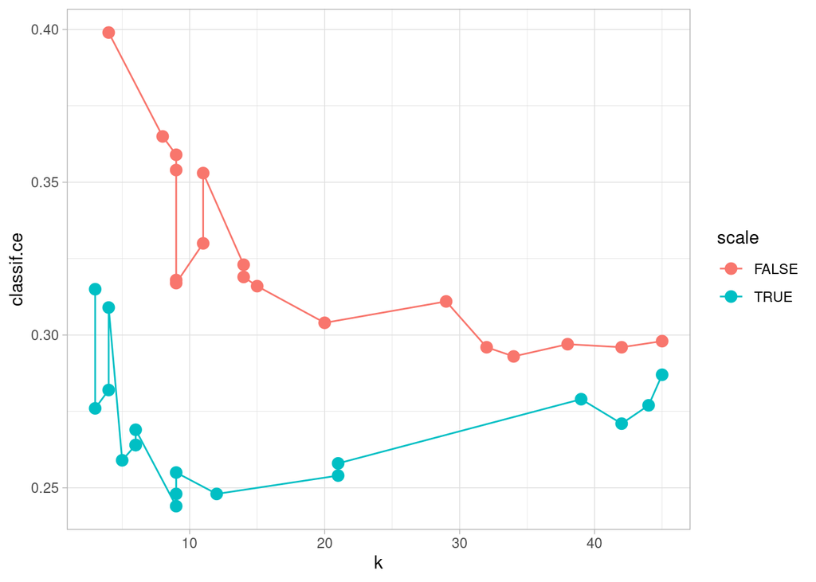

```r
ggplot(perfdata, aes(x = k, y = classif.ce, color = scale)) +
  geom_point(size = 3) + geom_line()
```

- As for the kernel, there does not seem to be a strong influence:

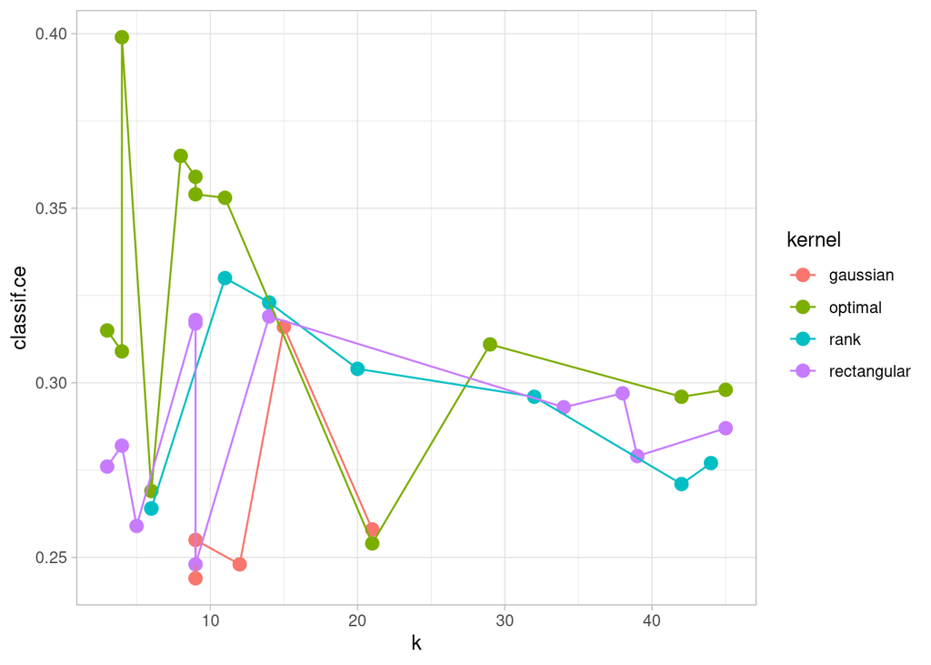

```r
ggplot(perfdata, aes(x = k, y = classif.ce, color = kernel)) +
  geom_point(size = 3) + geom_line()
```

# Nested Resampling

What performance do we expect from our tuned method? Naive evaluation:

```r
instance_random$result$perf
```

```
#> classif.ce
#>      0.244
```

```r
instance_grid$result$perf
```

```
#> classif.ce
#>      0.253
```

- Problem: *overtuning*:
  - The more we search, the more our result is likely to just be “lucky” on your training data
  - Imagine predicting random values and “tuning” the seed value. If we try enough seeds we may get good (tuning set) performance!
  - Different search spaces or search methods may introduce different amounts of randomness, so even the comparison is flawed!
- Solution: Nested Resampling

The `mlr3tuning` package provides an `AutoTuner` that acts like our tuning method is actually a `Learner`!

- `$train()` method:
  - Tune hyperparameters on the training data, using a resampling strategy (below 5 fold CV).
  - Train a model with optimal hyperparameters on whole training data.
- `$predict()` method: use model trained on the whole training data as model.
- This is just the workflow we use when tuning hyperparameters: Find the best parameters and use them for training.
- The `AutoTuner` does exactly this.

```r
grid_auto = AutoTuner$new(
  learner = knn,
  resampling = rsmp("cv", folds = 5), # we can NOT use fixed resampling here
  measures = msr("classif.ce"),
  tune_ps = searchspace,
  terminator = term("none"),
  tuner = tnr("grid_search", resolution = 18)
)
```

- The autotuner behaves just like a `Learner`. It can be used to combine the steps of hyperparameter tuning and model fitting, but is especially useful for resampling and fair comparison of performance through benchmarking.

```r
resample(task, grid_auto, cv10_instance)$aggregate()
```

```
#> classif.ce
#>      0.253
```

- Essentially this is the performance of a “knn with optimal hyperparameters found by grid search”

# Appendix

## Example: Tuning With Larger Budget

It is always interesting to look at what could have been. The following dataset contains an optimization run result with 3600 evaluations–more than above by a factor of 100.

```r
perfdata = readRDS("randomsearch_3600.rds")
```

- The scale effect is just as visible.

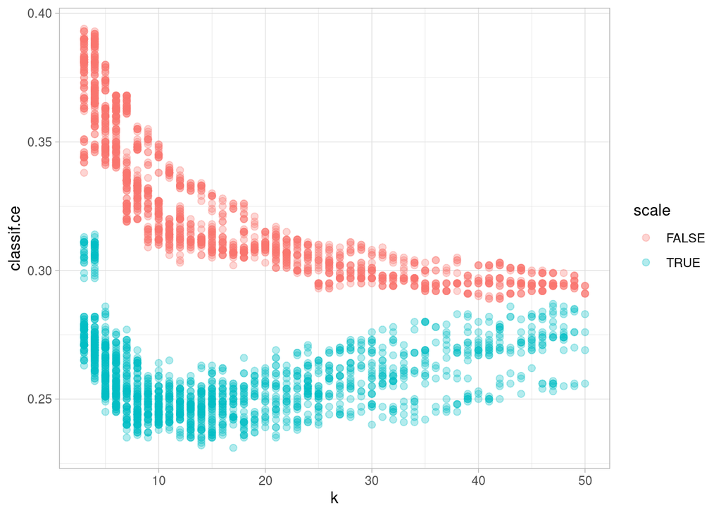

```r
ggplot(perfdata, aes(x = k, y = classif.ce, color = scale)) +
  geom_point(size = 2, alpha = 0.3)
```

- There seems to be a pattern by kernel as well…

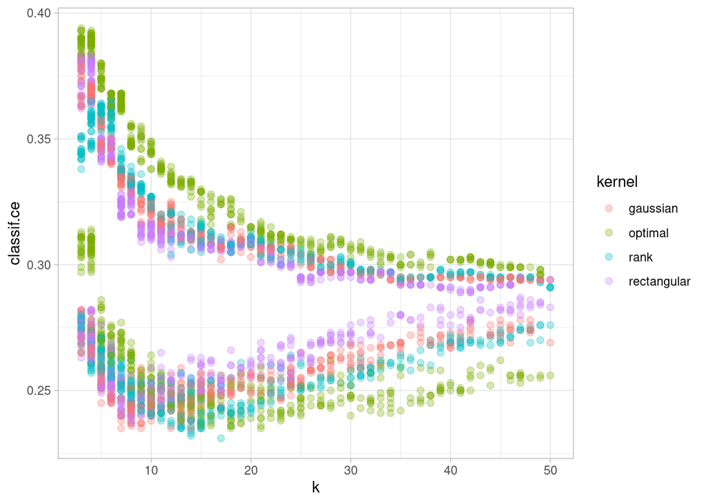

```r
ggplot(perfdata, aes(x = k, y = classif.ce, color = kernel)) +
  geom_point(size = 2, alpha = 0.3)
```

- In fact, if we zoom in to `(5, 30)` x `(0.2, 0.3)` and do loess smoothing we see that different kernels have their optimum at different `k`.

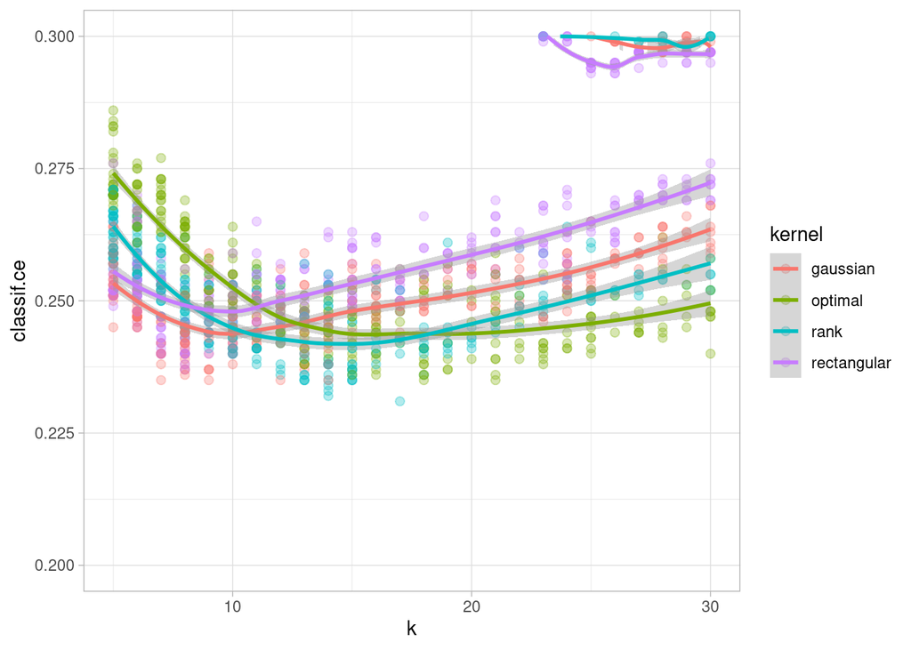

```r
ggplot(perfdata, aes(x = k, y = classif.ce, color = kernel,
  group = interaction(kernel, scale))) +
  geom_point(size = 2, alpha = 0.3) + geom_smooth() +
  xlim(5, 30) + ylim(0.2, 0.3)
```

- What about the `distance` parameter? If we select all results with `k` between 10 and 20 and plot distance and kernel we see an approximate relationship

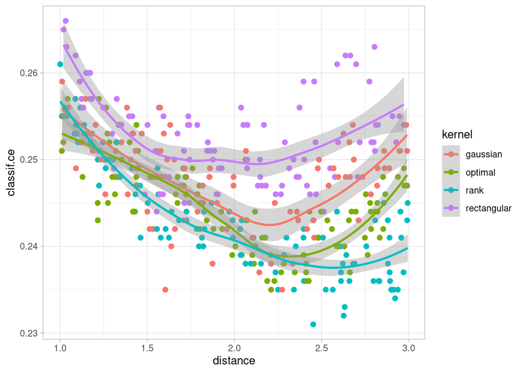

```r
ggplot(perfdata[k > 10 & k < 20 & scale == TRUE],
  aes(x = distance, y = classif.ce, color = kernel)) +
  geom_point(size = 2) + geom_smooth()
```

- Observations:
  - The `scale` makes a lot of difference
  - The `distance` seems to make the least difference
  - Had we done grid search, we would have wasted a lot of evaluations on trying different `distance` values that usually give similar results. This is why random search works well.
  - An even more intelligent approach would be to observe that `scale = FALSE` performs badly and not try out so many points with that one.

## Very quick `paradox` primer

Initialization:

```r
ParamSet$new(list( <PARAMETERS> ))
```

Possible parameter types:

```r
# - logical (values TRUE, FALSE)
ParamLgl$new("parameter_id")
# - factorial (discrete values from a list of 'levels')
ParamFct$new("parameter_id", c("value1", "value2", "value3"))
# - integer (from 'lower' to 'upper' bound)
ParamInt$new("parameter_id", lower = 0, upper = 10)
# - numeric (from 'lower' to 'upper' bound)
# - unfortunately named after the storage type, "double precision floating point"
ParamDbl$new("parameter_id", lower = 0, upper = 10)

# Also possible: "untyped", but we can not tune with this!
ParamUty$new("parameter_id")
```

So an example parameter set with one logical parameter `"flag"` and one integer parameter `"count"`:

```r
ParamSet$new(list(
  ParamLgl$new("flag"),
  ParamInt$new("count", lower = 0, upper = 10)
))
```

```
#> ParamSet:
#>       id    class lower upper      levels     default value
#> 1:  flag ParamLgl    NA    NA  TRUE,FALSE <NoDefault>
#> 2: count ParamInt     0    10             <NoDefault>
```

See the [online vignette](https://mlr3book.mlr-org.com/paradox.html) of `paradox` for a more complete introduction.